# Project Final - Predicting Alzheimer’s and Stroke

- Show All Code
- Hide All Code
- View Source

Author

Jack Brown, Dominic Maranta, and Phin Horowitz

## Context

Serious brain related health issues like Alzheimer’s and Stroke have been a persistent crisis that organizations like yours have been striving to prevent and mitigate for many years. We have developed some treatments for these ailments, but we are still working towards better ways to discover who is most at risk. Research done by the World Health Organization in 2022 has shown that the risk of developing a stroke has increased by 50% over the last 17 years and that currently, 1 in 4 people is estimated to have a stroke in their lifetime. For Alzheimer’s, data from your website (The Alzheimer’s association) has shown that more than 6 million Americans are living with Alzheimer’s and project that by 2050, this number will rise to nearly 13 million. These are growing problems across the globe and gaining a better understanding of how to predict these diseases and what the leading causes are is vital to your work of helping millions of patients. In this paper, we are attempting to use predictive statistical modeling in order to gain insight into what specific variables are having the biggest effect on people developing these diseases, as well as provide a way to predict what patients might be at a higher risk of problems.

## Introduction

Your organizations, the American Stroke Association and the Alzheimer’s Association, can greatly benefit from predictive modeling into brain related ailments. By creating and delivering a predictive model we can assist your organizations in identifying key risks of these diseases and assist doctors in making proper diagnoses and quickly begin preventative or early treatment. This project is split into two fields of brain related ailments, either the stroke or Alzheimer’s. We hope to specifically identify the unique risk factors associated with each of these diseases to further the study of brain related illness in the medical field. While these ailments are not specifically related, they impact similar parts of the body and a great body of work exists in preventing, diagnosing, and treating both of these brain ailments. Our research and model building will be delivered to your organizations in the hopes of identifying stroke and Alzheimer’s hazards. Your organizations can disperse this modeling to doctors around the country to help these individuals provide more accurate diagnostics for their patients and further educate these patients on the risks and prevention methods.

In order to build these predictive models, we have gathered two datasets on Alzheimer’s and stroke patients. These datasets were found online and will be provided below in our preliminary investigation. Our Alzheimer’s dataset was provided by The [Open Access Series of Imaging Studies (OASIS)](http://www.oasis-brains.org/), which is “a project aimed at making MRI data sets of the brain freely available to the scientific community”. By collecting and freely releasing their MRI data, they hope to inspire future discoveries in the clinical neuroscience space. OASIS data is managed and released by the Washington University Alzheimer’s Disease Research Center, Dr. Randy Buckner at the [Howard Hughes Medical Institute (HHMI)](http://www.hhmi.org/)( at Harvard University, the [Neuroinformatics Research Group (NRG)](http://nrg.wustl.edu/) at Washington University School of Medicine, and the [Biomedical Informatics Research Network (BIRN)](http://www.nbirn.net/). Further, our Stroke dataset was provided by McKinsey Healthcare, and it is normally used as a research example dataset for classroom problems and simulation. Nevertheless, each row in our dataset represents a patient of either ailment, and key demographic and health related information for our use in predictive modeling. In addition, we have the outcome diagnosis for all patients so that we can use our models under supervised learning, to train our model for future prediction use. In the stroke dataset we will use the “stroke” variable, which is a 1 if the patient had a stroke or a 0 if the patient did not have a stroke. This is our outcome variable on whether or not the patient in the study had a stroke. Additionally, we will use the following predictors with their values below.

1) gender: “Male”, “Female” or “Other”

2) age: age of the patient

3) hypertension: 0 if the patient doesn’t have hypertension, 1 if the patient has hypertension

4) heart_disease: 0 if the patient doesn’t have any heart diseases, 1 if the patient has a heart disease

5) ever_married: “No” or “Yes”

6) work_type: “children”, “Govt_jov”, “Never_worked”, “Private” or “Self-employed”

7) Residence_type: “Rural” or “Urban”

8) avg_glucose_level: average glucose level in blood

9) bmi: body mass index

10) smoking_status: “formerly smoked”, “never smoked”, “smokes” or “Unknown”*

In the Alzheimer’s dataset we will use the CDR variable, or Clinical Dementia Rating, which is a doctor formulated score on a scale of 0 to 5, measuring the level of dementia in a patient, with 0 being no dementia and 5 being terminal dementia. This variable will help us to create classifications of the extent to which a patient suffers from Alzheimer’s or not.

For the Alzheimer’s data set we will use the following predictors with their values below.

Age --> Age in years

EDUC --> Years of Education

SES --> Socioeconomic Status / 1-5 where 1 is low and 5 is high

MMSE --> Mini Mental State Examination which is scored out of 30 questions, and measures cognitive impairment, with 30 being perfect and below 23 usually indicating some impairment

CDR --> Clinical Dementia Rating is a doctor formulated score on a scale of 0 to 5, measuring the level of dementia in a patient, with 0 being no dementia and 5 being terminal dementia

eTIV --> Estimated total intracranial volume is a measure of the total brain volume, where smaller volumes denote brain loss. Measured in mL.

nWBV --> Normalize Whole Brain Volume is a measure of the total head volume and is normalized on a scale between 0 and 1 where 1 is the largest brain recorded and 0 being none.

ASF --> Atlas Scaling Factor is a factor from MRI scans measuring brain expansion or contraction.

Most of the data is already cleaned and no variables need to be omitted. The only cleaning that needs to occur is making the numeric indicator variables factors for both datasets. Following this we will perform preliminary analyses and basic model fitting before moving on to more advanced modeling techniques for the best predictive ability.

Now we wanted to address some ethical considerations before moving on to more in depth research and analysis. The positive outcomes with our research is that individuals at risk for stroke or Alzheimer’s will have the benefit of risk education for their potential of both diseases. Both disease associations can gain knowledge on the field and help to educate doctors and patients on the risks of stroke or Alzheimer’s. Doctors can be assisted on diagnoses with predictive modeling to accurately diagnose both issues early to start preventative care or treatment. On the other hand, there are some concerns with equity. Doctors or groups in rural or low income regions who may not have access to running the predictive modeling may not gain access to our modeling. These groups may be left without these computer assisted diagnostics and left with regular diagnostics and treatment. Hopefully equitable access can be achieved to help rural or low income areas catch up in diagnostic modeling for these two diseases. Further, every statistical model will always have some error, and lead us to wrong predictions or assessments of risk. This could lead to someone who is not at risk of a brain ailment to be worried and make drastic lifestyle changes, when drastic changes were not necessarily required. We must be careful with our validation and disbursement of these resources to ensure our work is being used for the good of the people and that we get the maximum benefit out of these models.

Additionally, there are no names or identifiers with the dataset so we need not worry about confidentiality of our subjects. There is no way to match up the demographics with the patient. Of course, it is always best to be safe with the data so it will be smart to provide organizations with the trained model but be careful with which demographic information we are sharing.

Finally, we will give this modeling to your two organizations with education and warnings of potential downsides such as inequity of use. We will work with your associations to develop a plan to use this model equally in doctor’s offices and in risk education programs to make sure equity is kept in the model’s use. Communication and monitoring are key to ensuring the proper use of this model for healthcare.

## Previous Work

1. https://citeseerx.ist.psu.edu/document?repid=rep1&type=pdf&doi=b6985d127a1c419edca437f4c71589e744699b44

This report from 2012 called “Effective Analysis and Predictive Model of Stroke Disease using Classification Methods” details the creation of a predictive model using similar methods to ones we have learned about in class, mainly decision trees and classification methods, as well as methods we haven’t discussed (naive bayes, and neural networks) in order to create a predictive model for stroke disease. Their dataset mainly uses specific symptoms and the amount of years patients have been experiencing them for, and predicts the likelihood and timing of a stroke for each patient. Our model will be unique by incorporating other variables, such as outside factors about each patient’s lives and separate symptoms that aren’t necessarily correlated with strokes. We will also examine Alzhiemer’s, which isn’t included in this article’s model.

2. https://link.springer.com/article/10.1186/s12883-021-02276-8

This report from 2021 called “Construction of a risk prediction model for Alzheimer’s disease in the elderly population” uses data from 1099 elderly people obtained through clinical data and questionnaires. 9 variables were studied using LASSO, regression analysis was used to select the best predictor variables, and multivariate logistic regression analysis was used to construct the prediction model. Their variables are similar to ours (age, economic status, etc) but we have a wider variable pool and will also study the interaction between these 2 cognitive diseases which will expand on their model. We also have a wider range of ages, not focusing specifically on the elderly.

## Data Setup

### Alzheimer’s

```r
alz <- read_csv("C:\\Users\\domar\\OneDrive\\Documents\\STAT 551\\alzheimer.csv")
alz <- alz %>% drop_na()
```

```r
alz %>% head()
```

```
# A tibble: 6 × 10
  Group       `M/F`   Age  EDUC   SES  MMSE   CDR  eTIV  nWBV   ASF
  <chr>       <chr> <dbl> <dbl> <dbl> <dbl> <dbl> <dbl> <dbl> <dbl>
1 Nondemented M        87    14     2    27   0    1987 0.696 0.883
2 Nondemented M        88    14     2    30   0    2004 0.681 0.876
3 Nondemented F        88    18     3    28   0    1215 0.71  1.44
4 Nondemented F        90    18     3    27   0    1200 0.718 1.46
5 Nondemented M        80    12     4    28   0    1689 0.712 1.04
6 Nondemented M        83    12     4    29   0.5  1701 0.711 1.03
```

```r
alz %>% summary()
```

```
    Group               M/F                 Age             EDUC
 Length:354         Length:354         Min.   :60.00   Min.   : 6.00
 Class :character   Class :character   1st Qu.:71.00   1st Qu.:12.00
 Mode  :character   Mode  :character   Median :77.00   Median :15.00
                                       Mean   :77.03   Mean   :14.70
                                       3rd Qu.:82.00   3rd Qu.:16.75
                                       Max.   :98.00   Max.   :23.00
      SES            MMSE            CDR              eTIV
 Min.   :1.00   Min.   : 4.00   Min.   :0.0000   Min.   :1106
 1st Qu.:2.00   1st Qu.:27.00   1st Qu.:0.0000   1st Qu.:1358
 Median :2.00   Median :29.00   Median :0.0000   Median :1470
 Mean   :2.46   Mean   :27.41   Mean   :0.2712   Mean   :1490
 3rd Qu.:3.00   3rd Qu.:30.00   3rd Qu.:0.5000   3rd Qu.:1595
 Max.   :5.00   Max.   :30.00   Max.   :2.0000   Max.   :2004
      nWBV             ASF
 Min.   :0.6440   Min.   :0.876
 1st Qu.:0.6990   1st Qu.:1.100
 Median :0.7290   Median :1.194
 Mean   :0.7299   Mean   :1.194
 3rd Qu.:0.7570   3rd Qu.:1.292
 Max.   :0.8370   Max.   :1.587
```

```r
alz <- alz %>% rename(gender = 'M/F')

alz <- alz %>%
  mutate(
    Group = factor(Group),
    gender = factor(gender),
    CDR = factor(CDR)
  )
```

### Stroke

```r
stroke <- read_csv("C:\\Users\\domar\\OneDrive\\Documents\\STAT 551\\healthcare-dataset-stroke-data.csv")
stroke <- stroke %>% drop_na()
```

```r
stroke %>% head()
```

```
# A tibble: 6 × 12
     id gender   age hypertension heart_disease ever_married work_type
  <dbl> <chr>  <dbl>        <dbl>         <dbl> <chr>        <chr>
1  9046 Male      67            0             1 Yes          Private
2 51676 Female    61            0             0 Yes          Self-employed
3 31112 Male      80            0             1 Yes          Private
4 60182 Female    49            0             0 Yes          Private
5  1665 Female    79            1             0 Yes          Self-employed
6 56669 Male      81            0             0 Yes          Private
# … with 5 more variables: Residence_type <chr>, avg_glucose_level <dbl>,
#   bmi <chr>, smoking_status <chr>, stroke <dbl>
```

```r
stroke %>% summary()
```

```
       id           gender               age         hypertension
 Min.   :   67   Length:5110        Min.   : 0.08   Min.   :0.00000
 1st Qu.:17741   Class :character   1st Qu.:25.00   1st Qu.:0.00000
 Median :36932   Mode  :character   Median :45.00   Median :0.00000
 Mean   :36518                      Mean   :43.23   Mean   :0.09746
 3rd Qu.:54682                      3rd Qu.:61.00   3rd Qu.:0.00000
 Max.   :72940                      Max.   :82.00   Max.   :1.00000
 heart_disease     ever_married        work_type         Residence_type
 Min.   :0.00000   Length:5110        Length:5110        Length:5110
 1st Qu.:0.00000   Class :character   Class :character   Class :character
 Median :0.00000   Mode  :character   Mode  :character   Mode  :character
 Mean   :0.05401
 3rd Qu.:0.00000
 Max.   :1.00000
 avg_glucose_level     bmi            smoking_status         stroke
 Min.   : 55.12    Length:5110        Length:5110        Min.   :0.00000
 1st Qu.: 77.25    Class :character   Class :character   1st Qu.:0.00000
 Median : 91.89    Mode  :character   Mode  :character   Median :0.00000
 Mean   :106.15                                          Mean   :0.04873
 3rd Qu.:114.09                                          3rd Qu.:0.00000
 Max.   :271.74                                          Max.   :1.00000
```

```r
stroke <- stroke %>%
  mutate(
    gender = factor(gender),
    hypertension = factor(hypertension),
    heart_disease = factor(heart_disease),
    ever_married = factor(ever_married),
    Residence_type = factor(Residence_type),
    work_type = factor(work_type),
    bmi = as.numeric(bmi),
    smoking_status = factor(smoking_status),
    stroke = factor(stroke)
  ) %>%
  drop_na()
```

```r
stroke1 <- stroke[1:500,]
```

## Data Exploration

*The following two sections will explore and unravel the contents of both our Alzheimer’s and Stroke risk datasets. Doing this allows us to get a better understanding of how the data works, as well as which variables are most important or even potentially related. With this information and more, we can assess which types of models will best serve the purpose of our exploration and analysis, accounting for the type of data we have available.

### Alzheimer’s

```r
#Table 1
table(alz$CDR)
```

```
  0 0.5   1   2
206 110  35   3
```

Table 1 above displays the distribution of our response variable, Clinical Dementia Ratings, in our data. Clearly, our data is bottom heavy, in that we have more patients with lower levels of clinical dementia. The higher we go in dementia levels, the smaller and smaller sample sizes we get. As such, we should be careful with our analysis of a CDR rating of 2 as the sample size is tiny.

```r
#Table 2
table(alz$gender)
```

```
  F   M
204 150
```

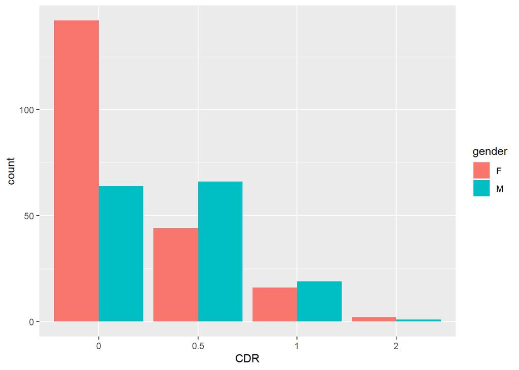

```r
#Graph 1
alz %>%
  ggplot(aes(x = CDR, fill = gender))+
  geom_bar(position = "dodge")
```

Gender does not appear to play a huge role in clinical dementia rating, however it does appear more males have dementia, but only in this sample so far.

Next, we will assess graphs of the distributions of our other explanatory variables, across each of the response variable’s, Clinical Dementia Rating’s, categories.

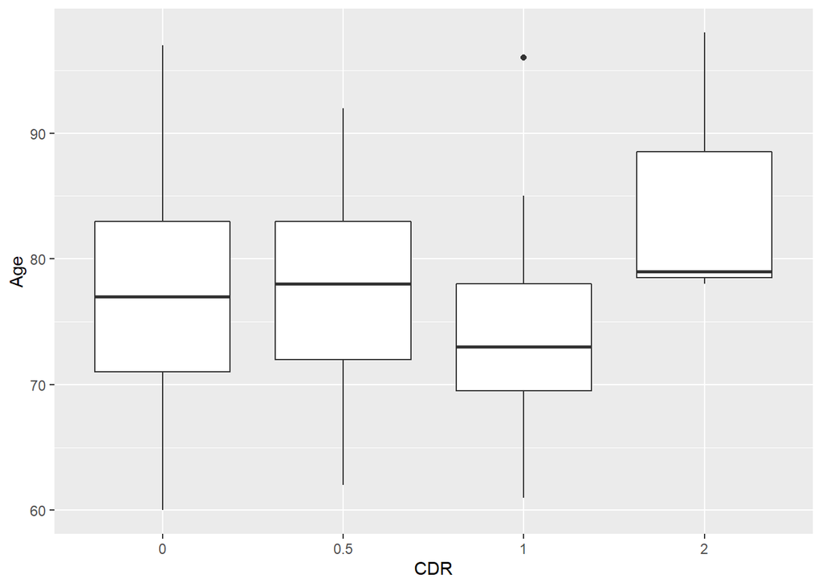

```r
#Graph 2
alz %>%
  ggplot(aes(x = CDR, y  = Age))+
  geom_boxplot()
```

Graph 2 above contains boxplots that visually display the Age distribution of our patients in each of the Clinical Dementia Ratings categories. From this, age does not appear to have a huge correlation alone with CDR, but there is intuitively a positive correlation between one’s age and their risk of developing dementia and Alzheimer’s. The age variable will be a key variable to keep in mind.

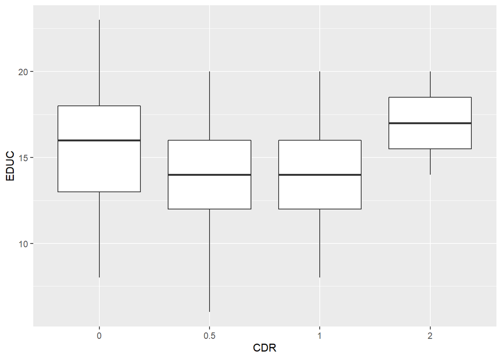

```r
#Graph 3
alz %>%
  ggplot(aes(x = CDR, y  = EDUC))+
  geom_boxplot()
```

Graph 3 above contains boxplots that visually display the distribution of Years of Education of our patients in each of the Clinical Dementia Ratings categories. From this, it seems that higher levels of education are loosely associated with lower CDR ratings, which logically makes sense with a stimulated mind. However, there is lots of variability and overlap of the ranges of Years of Education for each of the Clinical Dementia Ratings categories, so it is hard to draw any firm conclusions.

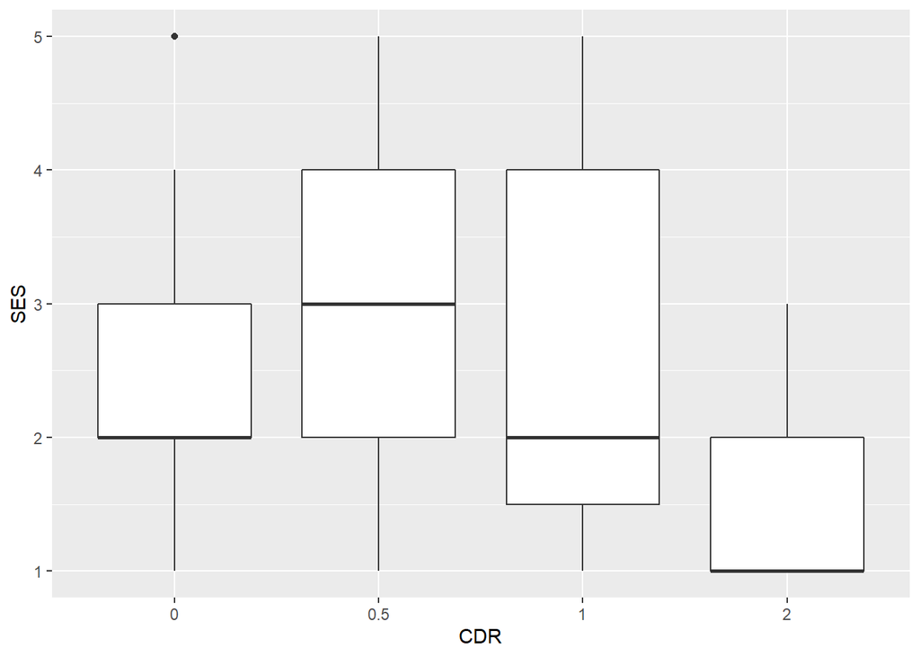

```r
#Graph 4
alz %>%
  ggplot(aes(x = CDR, y  = SES))+
  geom_boxplot()
```

Graph 4 above contains boxplots that visually display the distribution of Socio-Economic Status rating of our patients in each of the Clinical Dementia Ratings categories. Once again, there is variability and overlap of the ranges of Socio-Economic Status rating for each of the Clinical Dementia Ratings categories, so it does not appear that CDR and Social-Economic Status are associated alone.

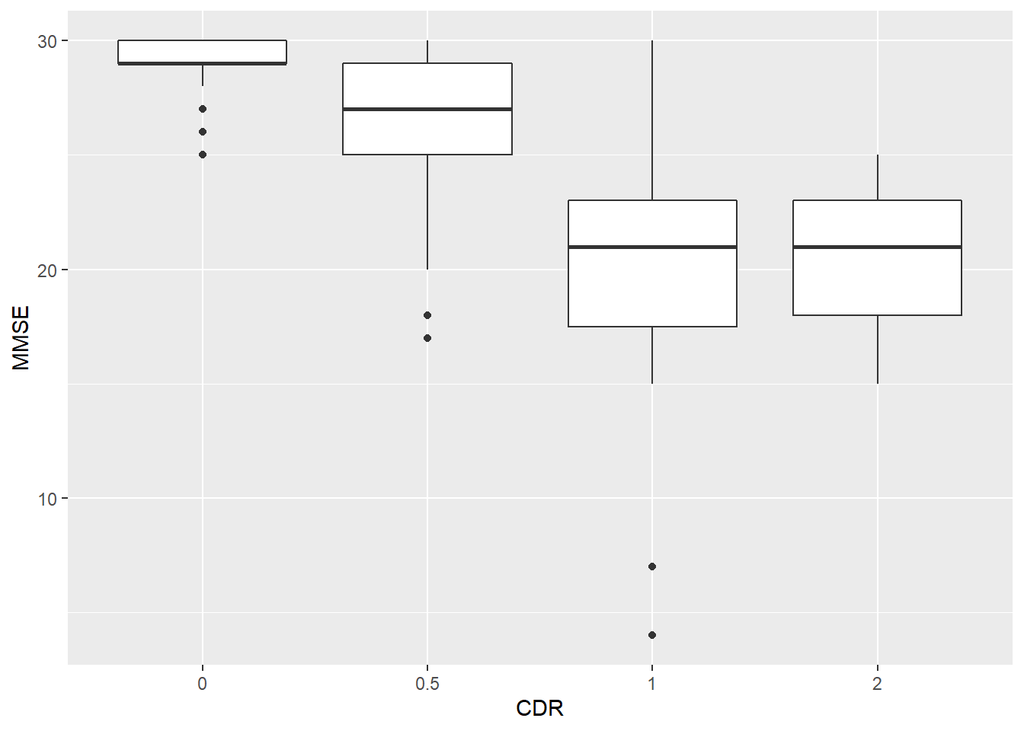

```r
#Graph 5
alz %>%
  ggplot(aes(x = CDR, y  = MMSE))+
  geom_boxplot()
```

Graph 5 above contains boxplots that visually display the distribution of Mini Mental State Examination scores of our patients in each of the Clinical Dementia Ratings categories. From this graph, it seems very apparent that lower scores on the mini mental state examination are associated with increased levels of Clinical Dementia Rating. This is very intuitive, as the main purpose of the Mini Mental State Examination is to assess patient’s dementia rating, with scores below 23 out of 30 signifying some signs of dementia-related impairment.

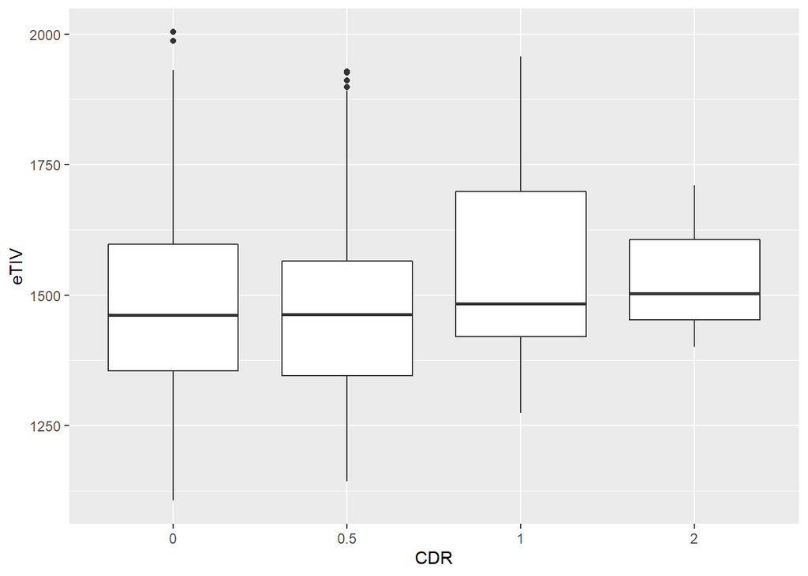

```r
#Graph 6
alz %>%
  ggplot(aes(x = CDR, y  = eTIV))+
  geom_boxplot()
```

Graph 6 above contains boxplots that visually display the distribution of Total Intracranial Volume of our patients in each of the Clinical Dementia Ratings categories. Once again, there is significant variability and overlap in the ranges of Total Intracranial Volume amount our patients in each of the Clinical Dementia Ratings categories, so it does not appear that Total Intracranial Volume and CDR are substantially associated.

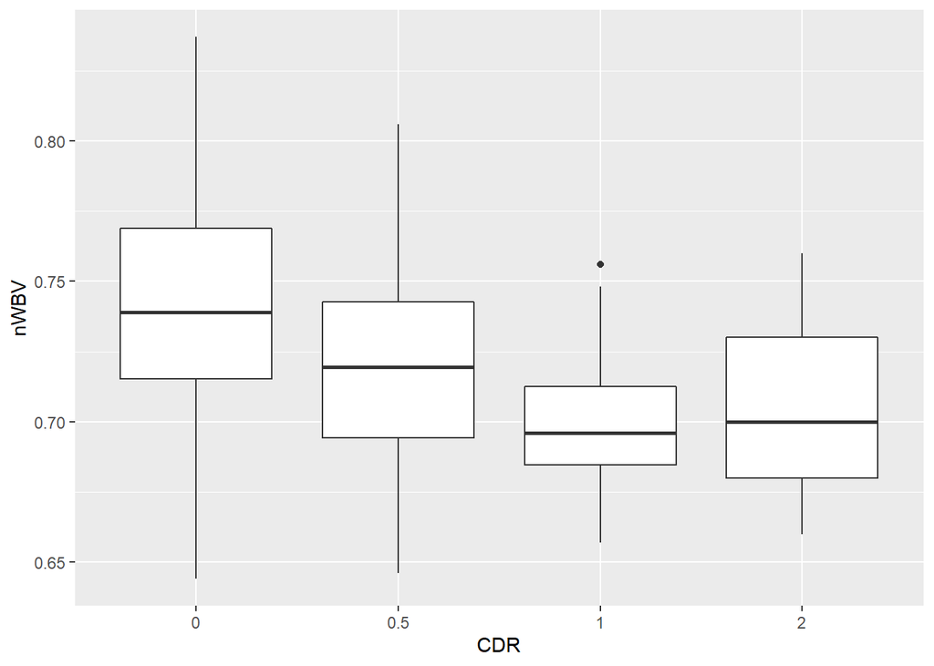

```r
#Graph 7
alz %>%
  ggplot(aes(x = CDR, y  = nWBV))+
  geom_boxplot()
```

Graph 7 above contains boxplots that visually display the distribution of Whole Brain Volume of our patients in each of the Clinical Dementia Ratings categories. Unlike with Total Intracranial Volume, there seems to be a much more apparent relationship between Whole Brain Volume and Clinical Dementia Ratings. Specifically, lower levels of Whole Brain Volume are associated with increased levels of dementia ratings and thus Alzheimer’s.

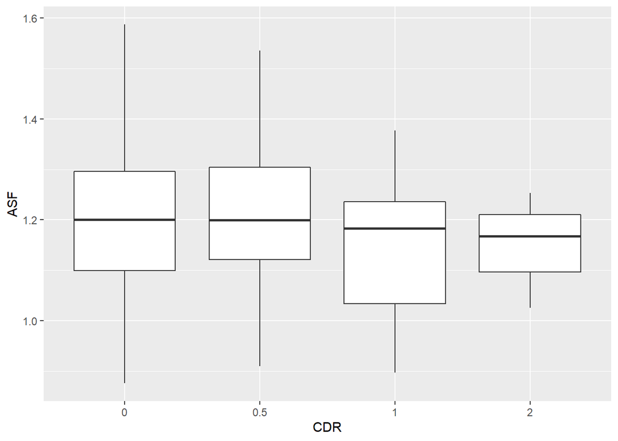

```r
#Graph 8
alz %>%
  ggplot(aes(x = CDR, y  = ASF))+
  geom_boxplot()
```

It does not appear that Atlas Scaling Factor is associated with Clinical Dementia Rating.

For the final part of our Alzheimer’s data exploration, we will look at scatterplots between variables we suspect to be associated or correlated.

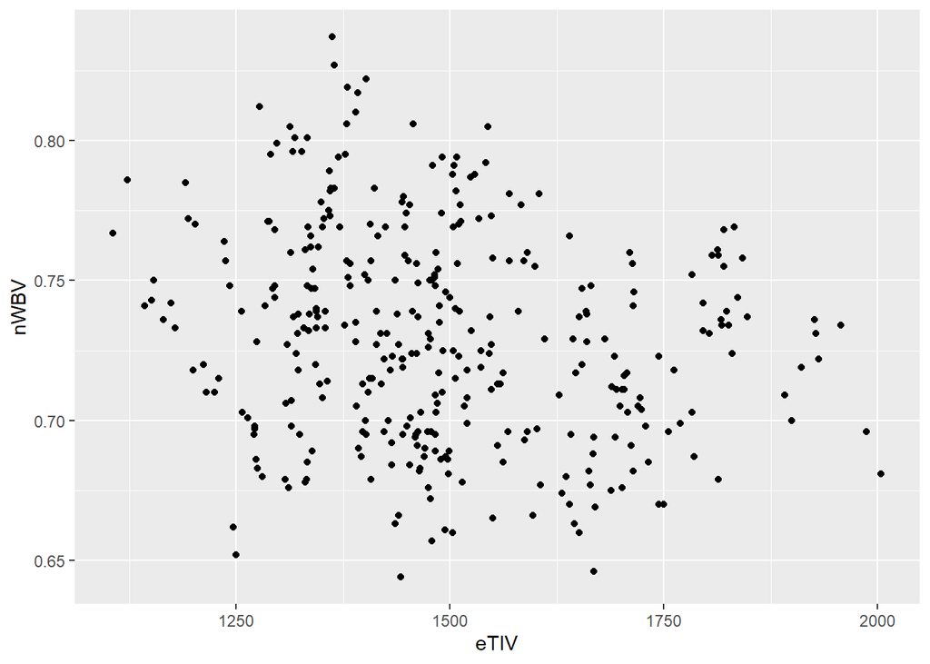

```r
#Graph 9
alz %>%
  ggplot(aes(x = eTIV, y  = nWBV))+
  geom_point()
```

Graph 9 above displays the Total Intracranial Volume values of patients against their Whole Brain Volume. From above, it is clear that Estimated Total Intracranial Volume is not associated with Whole Brain Volume. We expected this conclusion as we saw earlier that Whole Brain Volume visually appears to have a negative relationship with Clinical Dementia Rating, whereas Total Intracranial Volume had no apparent relationship at all. Therefore, it makes sense that these two variables are not directly related.

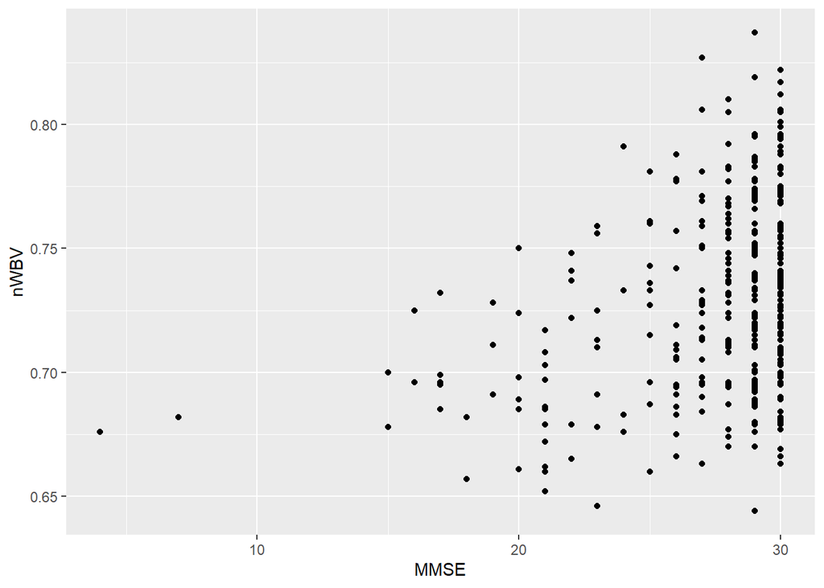

```r
#Graph 10
alz %>%
  ggplot(aes(x = MMSE, y  = nWBV))+
  geom_point()
```

Graph 10 above displays patient’s Mini Mental State Examination scores against their Whole Brain Volume value. From above, we see that Whole Brain Volume appears moderately correlated with Mini Mental State Examination. Once again, we somewhat expect this answer as we saw earlier that Whole Brain Volume visually appears to have a negative relationship with Clinical Dementia Rating. Moreso, as we also explained earlier, the main purpose of the Mini Mental State Examination is to assess patient’s dementia level. Therefore, it makes sense that Whole Brain Volume and Mini Mental State Examination scores have a noticeable relationship.

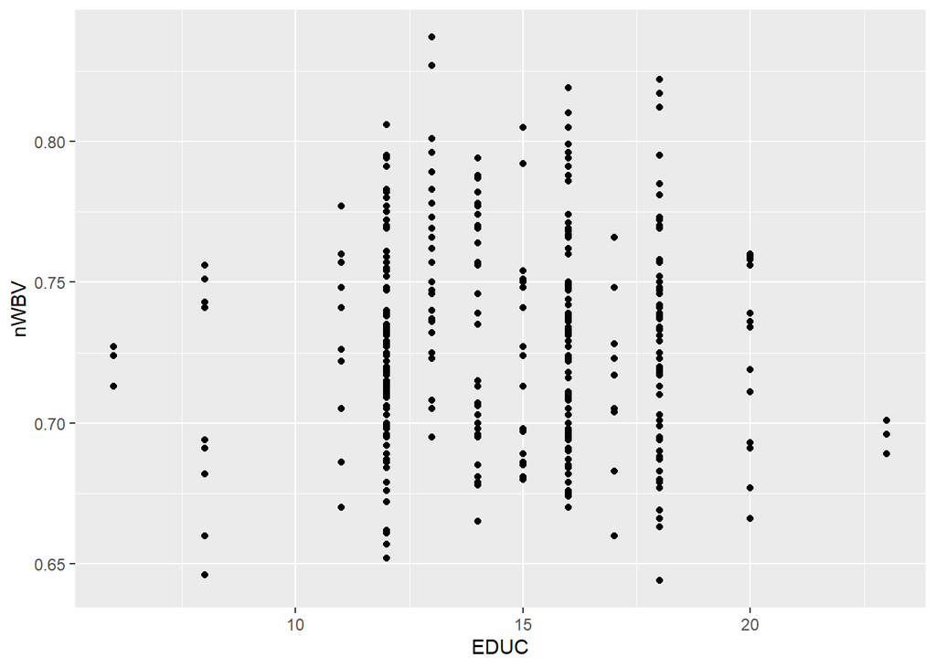

```r
#Graph 11
alz %>%
  ggplot(aes(x = EDUC, y  = nWBV))+
  geom_point()
```

Graph 11 above displays patient’s Years of Education against their Whole Brain Volume value. After assessing the graph above, we see that Whole Brain Volume appears to have no correlation at all to patients’ Years of Education, which is not particularly surprising.

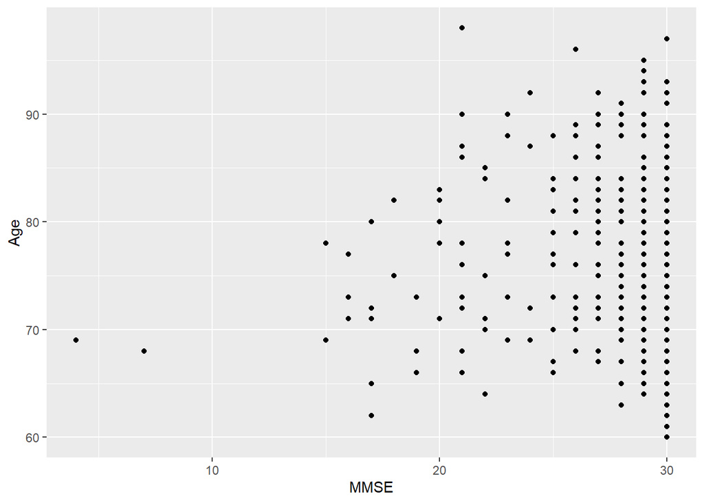

```r
#Graph 12
alz %>%
  ggplot(aes(x = MMSE, y  = Age))+
  geom_point()
```

Graph 12 above displays patient’s Mini Mental State Examination scores against their Age. Upon analyzing, we conclude that Age and MMSE are not associated, along with the rest of the combinations of the remaining predictor variables in our Alzheimer’s data set.

### Stroke

```r
#Table 3
table(stroke$stroke)
```

```
   0    1
4700  209
```

Table 3 above show us that our stroke data sample contains 209 subjects who did have a stroke and 4700 who did not.

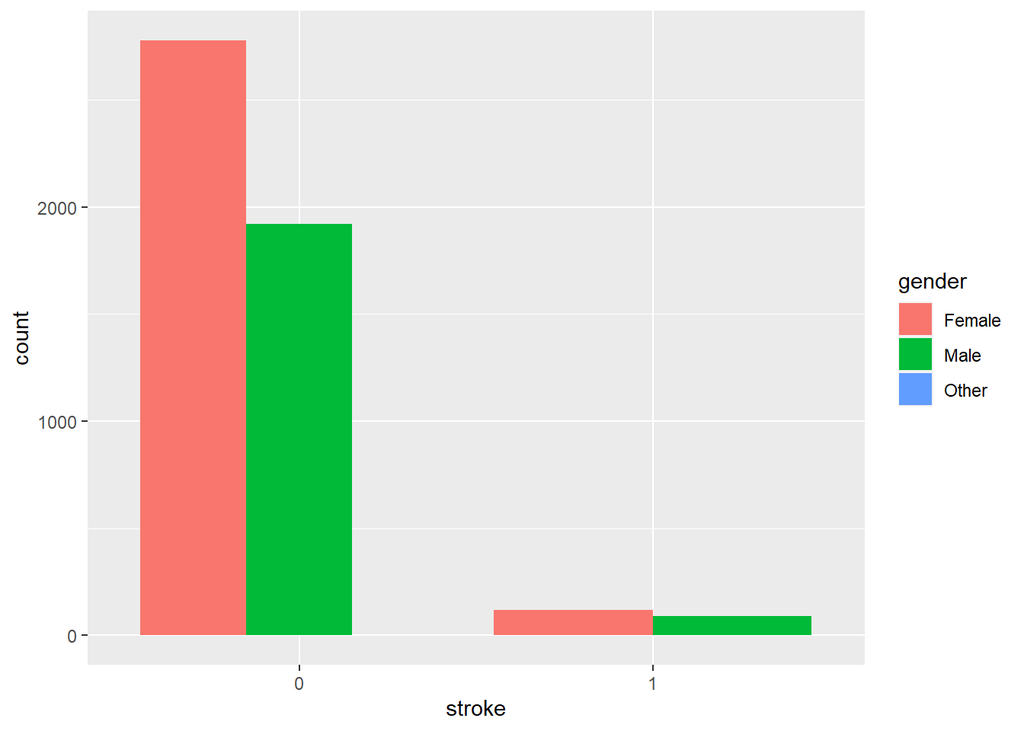

```r
#Graph 13
stroke %>%
  ggplot(aes(x = stroke, fill  = gender))+
  geom_bar(position = "dodge")
```

Graph 13 above shows the total number of strokes for both gender groups. Although females seem to have more strokes, our dataset contains more females than males. Therefore, we don’t have obvious evidence that gender and stroke are correlated.

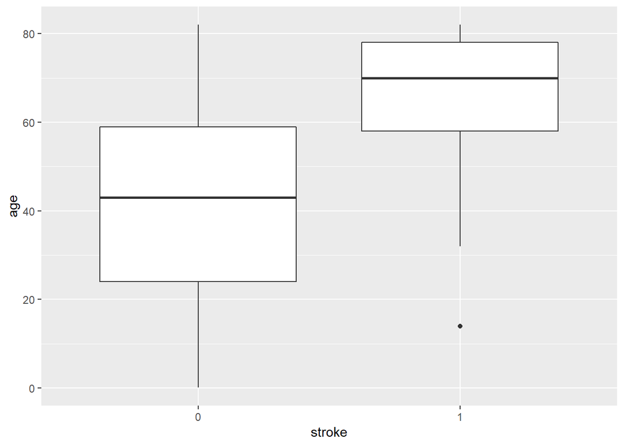

```r
#Graph 14
stroke %>%
  ggplot(aes(x = stroke, y  = age))+
  geom_boxplot()
```

According to Graph 14 above, Age appears to have a significant association with strokes where, as age increases, the amount of strokes does as well. This makes sense in context, as older people tend to be more prone to health issues and indicates that age could be an important variable in our model.

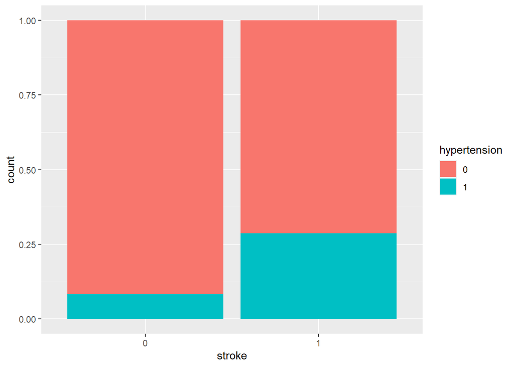

```r
#Graph 15
stroke %>%
  ggplot(aes(x = stroke, fill  = hypertension))+
  geom_bar(position = "fill")
```

```r
#Table 4
prop.table(table(stroke$hypertension, stroke$stroke), margin = 1)
```

```
             0          1
  0 0.96657694 0.03342306
  1 0.86696231 0.13303769
```

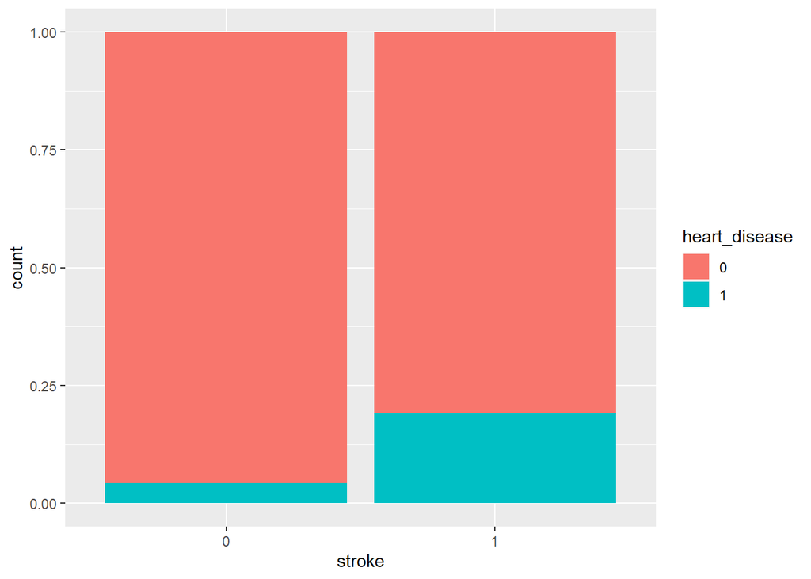

```r
#Graph 16
stroke %>%
  ggplot(aes(x = stroke, fill  = heart_disease))+
  geom_bar(position = "fill")
```

```r
#Table 5
prop.table(table(stroke$heart_disease, stroke$stroke), margin = 1)
```

```
             0          1
  0 0.96378054 0.03621946
  1 0.83539095 0.16460905
```

Graphs 15 and 16 as well as Tables 4 and 5 above illustrate a moderate correlation between stroke and both hypertension and heart disease, implying that those variables could be strong predictors of stroke in our final model. We should also investigate the correlation between these variables.

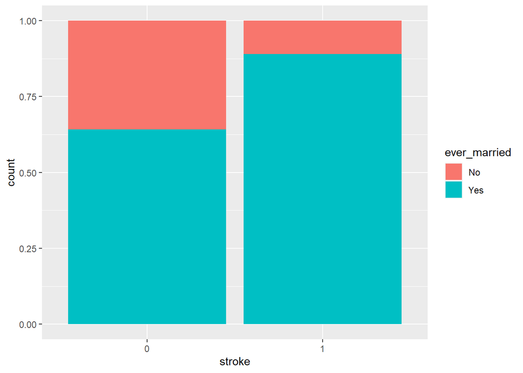

```r
#Graph 17
stroke %>%
  ggplot(aes(x = stroke, fill  = ever_married))+
  geom_bar(position = "fill")
```

Observing Graph 17 above, having a stroke and ever being married seem to have have a weak correlation, but of those who had stroke, more of them were married. In our data, about 63% of those who have never had a stroke have been married, where as about 88% percent of those who have had a stroke have been married.

```r
#Table 6
prop.table(table(stroke$work_type, stroke$stroke), margin = 1)
```

```
                          0           1
  children      0.998509687 0.001490313
  Govt_job      0.955555556 0.044444444
  Never_worked  1.000000000 0.000000000
  Private       0.954820349 0.045179651
  Self-employed 0.931612903 0.068387097
```

According to Table 6 above, stroke does not appear to be correlated with job type, except for a potential correlation with self-employed workers having more strokes.

```r
#Table 7
prop.table(table(stroke$Residence_type, stroke$stroke), margin = 1)
```

```
                0         1
  Rural 0.9586606 0.0413394
  Urban 0.9562249 0.0437751
```

Assessing Table 7 above, residence type seems completely uncorrelated with stroke risk.

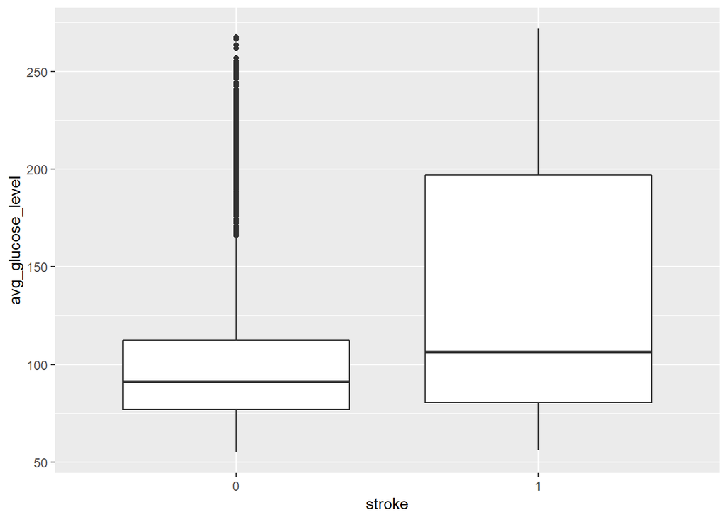

```r
#Graph 18
stroke %>%
  ggplot(aes(x = stroke, y  = avg_glucose_level))+
  geom_boxplot()
```

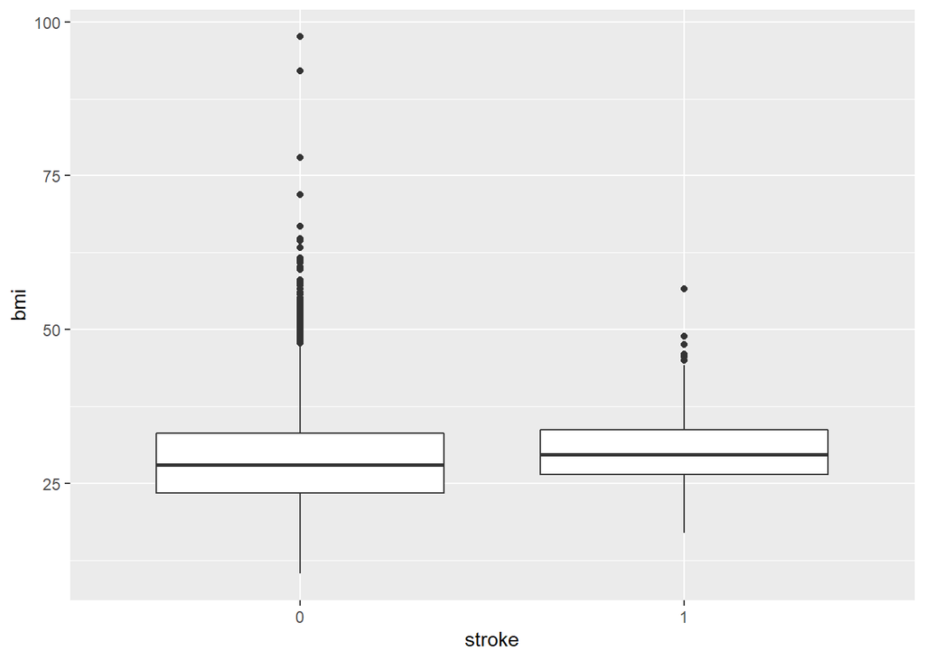

```r
#Graph 19
stroke %>%
  ggplot(aes(x = stroke, y  = bmi))+
  geom_boxplot()
```

According to Graph 19 above, BMI and stroke seem to be uncorrelated with each other.

```r
#Table 8
prop.table(table(stroke$smoking_status, stroke$stroke), margin = 1)
```

```
                           0          1
  formerly smoked 0.93189964 0.06810036
  never smoked    0.95464363 0.04535637
  smokes          0.94708277 0.05291723
  Unknown         0.98044504 0.01955496
```

Smoking seems slightly correlated with stroke, where smokers are more likely to have a stroke.

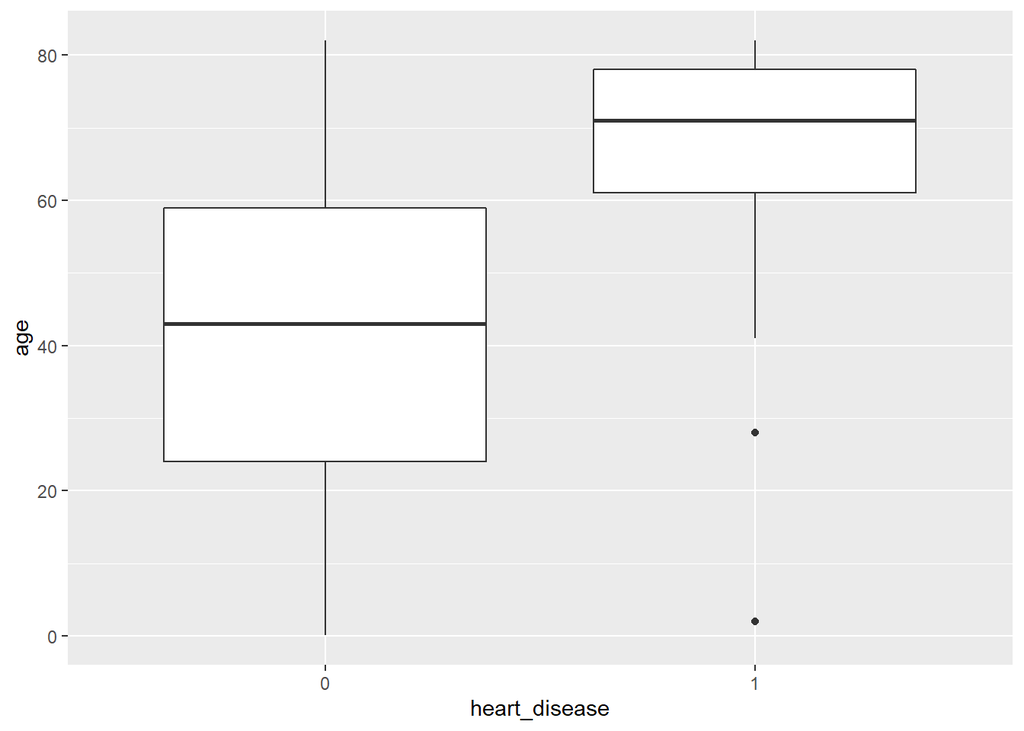

```r
#Graph 20
stroke %>%
  ggplot(aes(x = heart_disease, y  = age))+
  geom_boxplot()
```

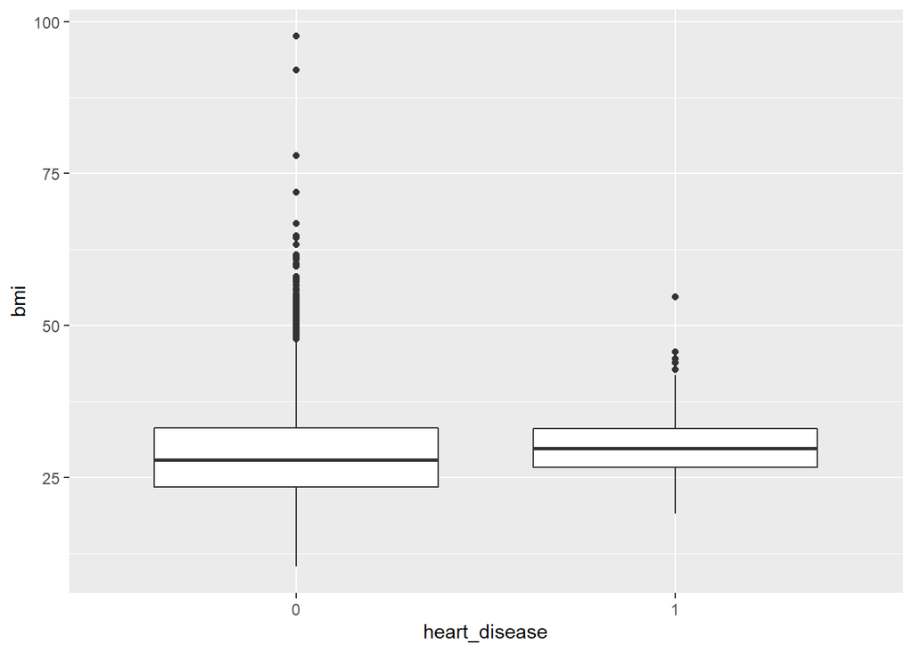

```r
#Graph 21
stroke %>%
  ggplot(aes(x = heart_disease, y  = bmi))+
  geom_boxplot()
```

Graph 20 above shows a very apparent positive relationship between age and heart disease. However, according to Graph 21 above, there appears to be no correlation between bmi and heart disease.

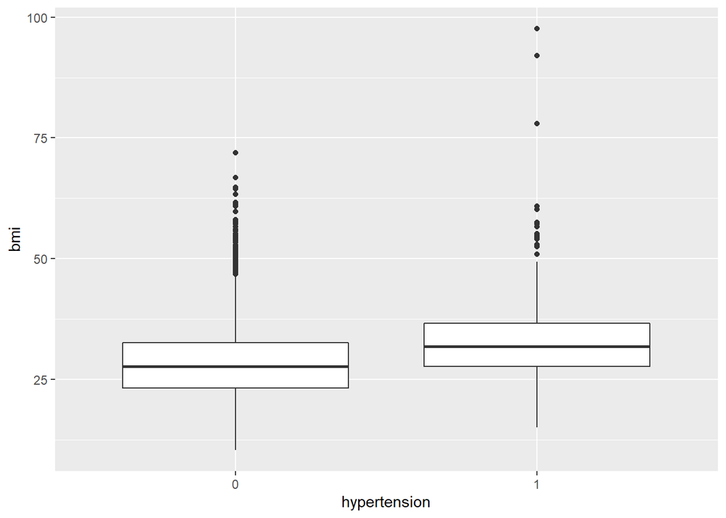

```r
#Graph 22
stroke %>%
  ggplot(aes(x = hypertension, y  = bmi))+
  geom_boxplot()
```

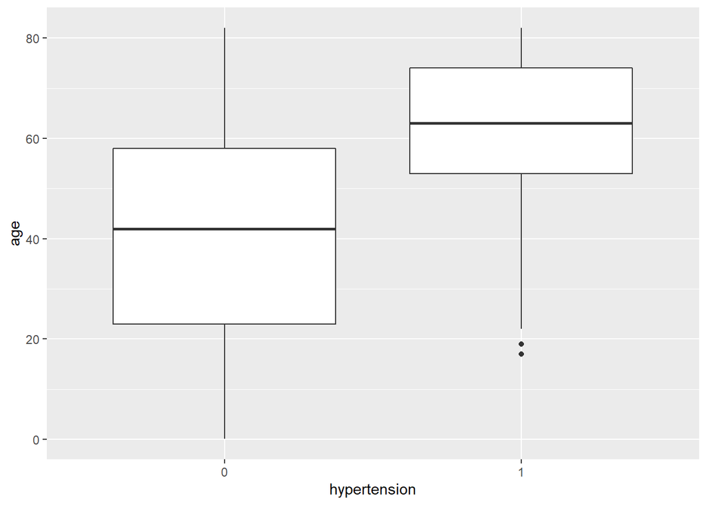

```r
#Graph 23
stroke %>%
  ggplot(aes(x = hypertension, y  = age))+
  geom_boxplot()
```

According to Graphs 22 and 23 above, hypertension appears to be somewhat correlated with both bmi and age.

```r
#Table 9
prop.table(table(stroke$smoking_status, stroke$heart_disease), margin = 1)
```

```
                           0          1
  formerly smoked 0.91636798 0.08363202
  never smoked    0.95626350 0.04373650
  smokes          0.92537313 0.07462687
  Unknown         0.97505057 0.02494943
```

```r
#Table 10
prop.table(table(stroke$smoking_status, stroke$hypertension), margin = 1)
```

```
                           0          1
  formerly smoked 0.86857826 0.13142174
  never smoked    0.88336933 0.11663067
  smokes          0.88873813 0.11126187
  Unknown         0.97100472 0.02899528
```

Table 9 above shows us that smoking status is correlated with heart disease. However, Table 10 shows that smoking status does not appear to be correlated with hypertension.

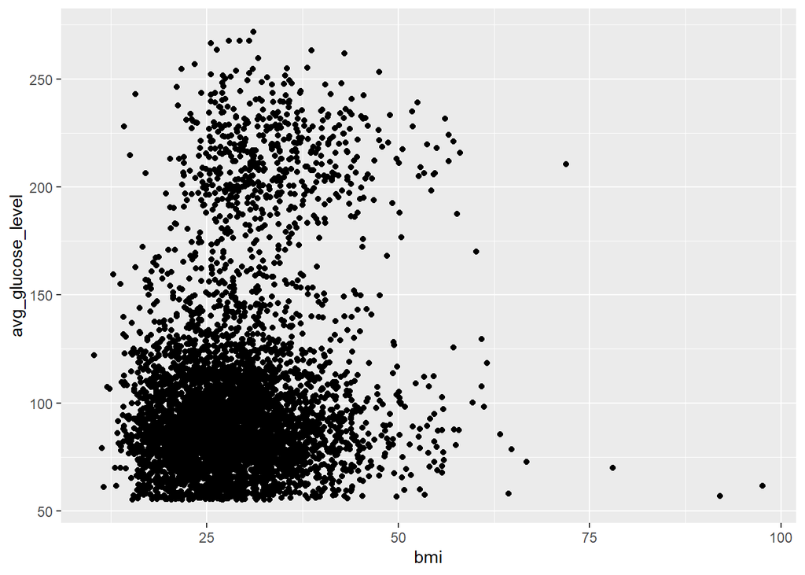

```r
#Graph 24
stroke %>%
  ggplot(aes(x = bmi, y  = avg_glucose_level))+
  geom_point()
```

Graph 24 above shows that BMI and average glucose levels are slightly correlated. The remainder of the predictors are mostly uncorrelated with each other.